# Understanding Linear Algebra for Machine Learning

## Basic ideas

1. Orginize information into a vector

Vector - a 1d array of numbers. It has a magnitude (length) and direction. Think of Illistrator and how it handles images with vectors instead of pixels.

The totality of all vectors with n entries is an n-dimensional vector space

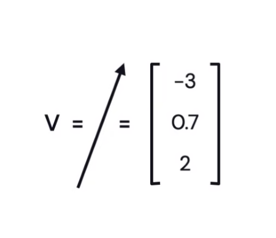

```python
#reading an image

import cv2
import numpy as np
from matplotlib import pyplot as plt

# Load the image
img = cv2.imread('vector.png')

# Convert the image from BGR to RGB
img_rgb = cv2.cvtColor(img, cv2.COLOR_BGR2RGB)

# Display the image
plt.imshow(img_rgb)
plt.axis('off')
plt.show()
```

## Feature Vectors

A feature vector whose entries represent the features of some object

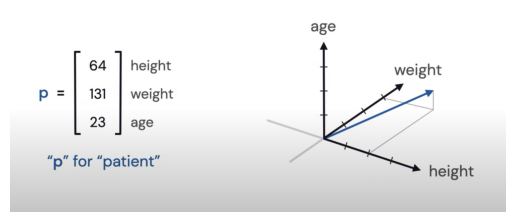

```python
#Example of the Feature vector

import cv2
import numpy as np
from matplotlib import pyplot as plt

# Load the image
img = cv2.imread('exvector.png')

# Convert the image from BGR to RGB
img_rgb = cv2.cvtColor(img, cv2.COLOR_BGR2RGB)

# Display the image
plt.imshow(img_rgb)
plt.axis('off')
plt.show()
```

A feature vector and a dictionary are both ways of representing data, but they are different in their structure and intended use.

A feature vector is a numerical representation of a set of features or attributes that describe an object or data point. Each entry in the vector corresponds to a specific feature, and the value of that entry represents the magnitude or importance of that feature. In the example you provided, the feature vector p = [64 131 23] represents the features height, weight, and age, respectively. This vector is often used in machine learning and data analysis to feed data into models that require numerical input.

On the other hand, a dictionary is a collection of key-value pairs, where each key represents a unique identifier for a piece of data, and the value represents the data itself. In the example you provided, the dictionary p = {height: 64, weight: 131, age: 23} also represents the features height, weight, and age, but in a different way. Here, each feature is associated with a label or key that identifies it, and the value associated with each key represents the actual measurement or value of that feature.

In summary, a feature vector is a numerical representation of a set of features or attributes, while a dictionary is a collection of key-value pairs that can represent any type of data, including feature vectors. While they can be used interchangeably in some contexts, they have different structures and intended uses.

In programming, a feature vector like p can be represented as an object, but a feature vector itself is not necessarily an object in the same way that a dictionary or a list is.

A feature vector is simply an ordered collection of numerical values that represent a set of features or attributes. It can be represented in various ways depending on the programming language or application, such as a list, tuple, or NumPy array.

However, some programming languages or libraries may define their own data structures or classes to represent feature vectors or other types of data. For example, in Python, you can create a class to represent a feature vector with methods to manipulate or analyze the vector.

So while a feature vector is not inherently an object, it can be represented as an object in some programming contexts.

Yes, a 1D array like p = [64, 131, 23] can be considered as a feature vector.

A feature vector is simply a list of numerical values that represent a set of features or attributes. In machine learning and data analysis, it is common to represent data as feature vectors, where each entry in the vector corresponds to a specific feature or attribute of the data.

The example you provided, p = [64, 131, 23], can be considered a feature vector because it contains three numerical values that represent the features height, weight, and age, respectively. This vector can be used as input to machine learning algorithms or other data analysis techniques that require numerical input in the form of feature vectors.

Note that in some machine learning libraries, such as NumPy or scikit-learn in Python, feature vectors are commonly represented as 1D arrays. Therefore, a 1D array like p = [64, 131, 23] can also be considered a feature vector in that context.

In machine learning, feature vectors (which can be represented as 1D arrays) are commonly used to represent the input data that is fed into machine learning models. Feature vectors offer several advantages over other data structures like dataframes, including:

1. Numerical representation: Machine learning models typically require numerical data as input. Feature vectors provide a convenient and efficient way to represent the data in a numerical format that can be easily processed by machine learning algorithms.
2. Consistent format: Feature vectors have a consistent format, where each entry in the vector corresponds to a specific feature or attribute of the data. This makes it easy to compare and analyze different data points using the same set of features.
3. Efficient storage and processing: Feature vectors require less storage space and are more efficient to process than other data structures like dataframes. This is especially important when working with large datasets, where efficiency is critical.
4. Simplified feature engineering: Feature vectors can be easily manipulated and transformed to create new features or perform feature engineering. This can be done using mathematical operations, such as adding or multiplying different features, or by applying more complex transformations like PCA or feature scaling.

Overall, feature vectors (represented as 1D arrays) are a simple and effective way to represent input data in machine learning. They provide a numerical representation of the data that is consistent, efficient, and easy to process, making them an essential tool for machine learning practitioners.

As an AI language model, I am not able to produce visual images like a graphic designer or artist. However, I can describe how a feature vector like p = [64, 131, 23] might be represented graphically when being fed into a machine learning algorithm.

One possible way to represent a feature vector graphically is to use a scatter plot, where each data point is represented as a point in a two-dimensional plane. Since p has three features, we can represent each data point as a point in a three-dimensional space, where the x-axis represents the height feature, the y-axis represents the weight feature, and the z-axis represents the age feature.

To visualize how p = [64, 131, 23] might be represented graphically, we can plot a single point in this three-dimensional space with coordinates (64, 131, 23), which represents the values of the height, weight, and age features for this data point.

Keep in mind that this is just one possible way to represent a feature vector graphically, and there are many other techniques that can be used depending on the context and the specific machine learning algorithm being used.

Yes, you can think of a feature vector like p = [64, 131, 23] as a point in a three-dimensional space, where each feature corresponds to one of the three axes of the space.

In this case, the height feature is represented by the x-axis, the weight feature is represented by the y-axis, and the age feature is represented by the z-axis. The point (64, 131, 23) represents the location of the data point in this three-dimensional space, with its position determined by the values of the three features.

This geometric interpretation of feature vectors is useful in understanding how machine learning algorithms operate on the data. For example, some machine learning algorithms seek to separate data points in this three-dimensional space using planes or other geometric shapes, in order to classify the data or make predictions about new data points.

However, it's important to note that the specific representation of a feature vector as a point in a three-dimensional space is just one way to conceptualize the data, and there are many other mathematical and statistical techniques used in machine learning that don't rely on this geometric interpretation.

Flattening matrixes into 1d arrays for machine learning processing

Say you have a 2d image, you convert it into a 2d matrix, then basically transpose each row into a column one by one into a 1d array or vector

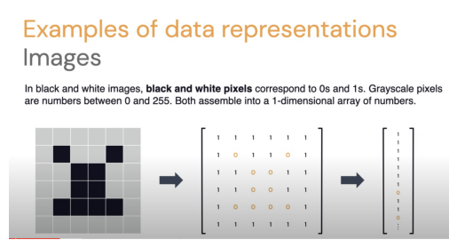

```python
#Example of the Feature vector

import cv2
import numpy as np
from matplotlib import pyplot as plt

# Load the image
img = cv2.imread('ex2vector.png')

# Convert the image from BGR to RGB
img_rgb = cv2.cvtColor(img, cv2.COLOR_BGR2RGB)

# Display the image
plt.imshow(img_rgb)
plt.axis('off')
plt.show()
```

Another example of how a 1d array is usefull is if we wanted to go through all the wikipedia pages and do a cound for each time the word dog apeared

This can be used in Latend semantic analysis

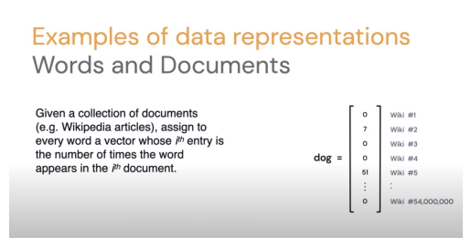

```python
#Example of the Feature vector

import cv2
import numpy as np
from matplotlib import pyplot as plt

# Load the image
img = cv2.imread('ex3vector.png')

# Convert the image from BGR to RGB
img_rgb = cv2.cvtColor(img, cv2.COLOR_BGR2RGB)

# Display the image
plt.imshow(img_rgb)
plt.axis('off')
plt.show()
```

One Hot Encoding

It is similar to get_dummies, but create individual 1 d arrays for each category

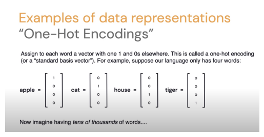

```python
#Example of the Feature vector

import cv2
import numpy as np
from matplotlib import pyplot as plt

# Load the image
img = cv2.imread('ex4vector.png')

# Convert the image from BGR to RGB
img_rgb = cv2.cvtColor(img, cv2.COLOR_BGR2RGB)

# Display the image
plt.imshow(img_rgb)
plt.axis('off')
plt.show()
```

Drawbacks of dummy variables and OHE. They don't pickup the nuanced relationship between categorical variables. Example from above image: a cat is more similar to a tiger than to an apple, but the OHE doesn't take that into consideration

Dot products

Is basically a way we can measure the similarities between 2 vectors

When we multiply 2 vectors, we get a single numeric value that can represent the measurable similarity bw the 2 vectors

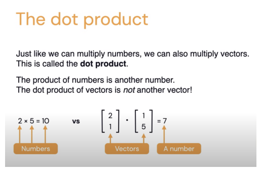

```python
# Load the image
img = cv2.imread('ex5vector.png')

# Convert the image from BGR to RGB
img_rgb = cv2.cvtColor(img, cv2.COLOR_BGR2RGB)

# Display the image
plt.imshow(img_rgb)
plt.axis('off')
plt.show()
```